# ARMA Processes

In this notebook I will give some examples for how to use some functions and tools related to the analysis of ARIMA processes.

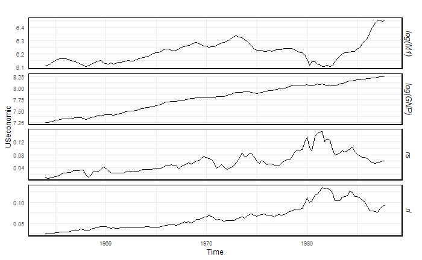

```r
# Start by importing a dataset
library(tseries)
library(forecast)
library(ggplot2)
data("USeconomic")
autoplot(USeconomic, facets = TRUE) + th
```

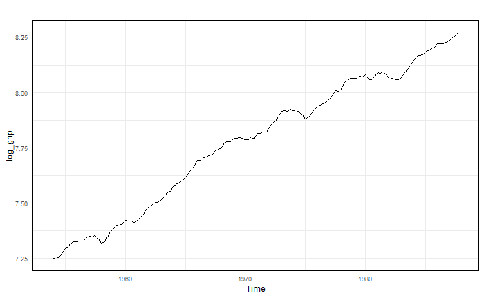

```r
# Extract the log_GNP series
log_gnp <- USeconomic[,"log(GNP)"]
autoplot(log_gnp) + th
```

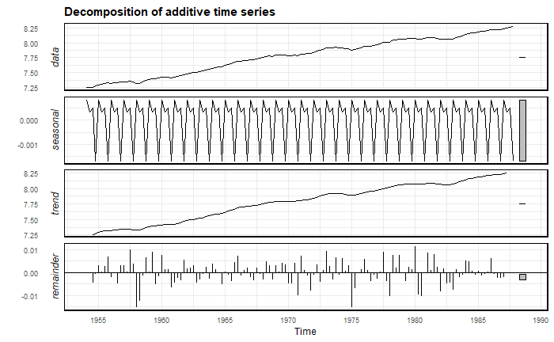

```r
# Time Series Decomposition
log_gnp_decomposition <- decompose(log_gnp)
autoplot(log_gnp_decomposition) + th
```

If you have a seasonal time series, you can seasonally adjust the series by estimating the seasonal component, and subtracting it from the original time series. In our case, we are going to difference the series instead.

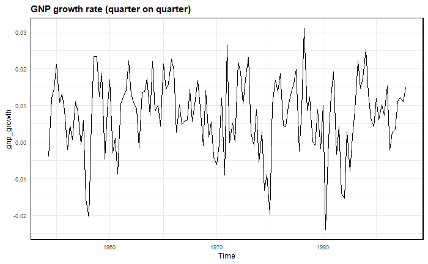

```r
#Differencing the time-series
gnp_growth <- diff(y, lag = 1)
#Plotting the data
autoplot(gnp_growth, main = "GNP growth rate (quarter on quarter)") + th
```

```r
# ADF test to check for stationarity
adf.test(gnp_growth)
```

```
p-value smaller than printed p-value
```

```
    Augmented Dickey-Fuller Test

data:  gnp_growth
Dickey-Fuller = -4.4101, Lag order = 5, p-value = 0.01
alternative hypothesis: stationary
```

We reject the null hypothesis that gnp_growth has a unit root: it is stationary. Since gnp_growth is stationary, we can apply the Box-Jenkins approach and try to fit a suitable ARMA model to the data. We wil start by examining the ACF and the PACF charts.

```
Ignoring unknown parameters: main
```

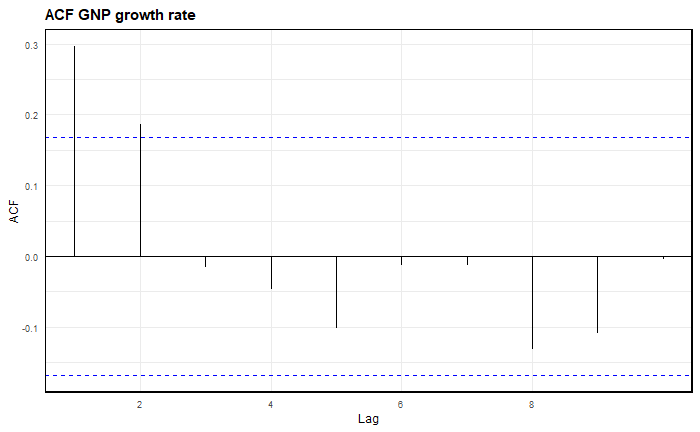

```r
#Plotting the estimated acf and pacf of GNP_growth
ggAcf(GNP_growth, lag.max = 10, main = "ACF GNP growth rate") + th
```

```
Ignoring unknown parameters: main
```

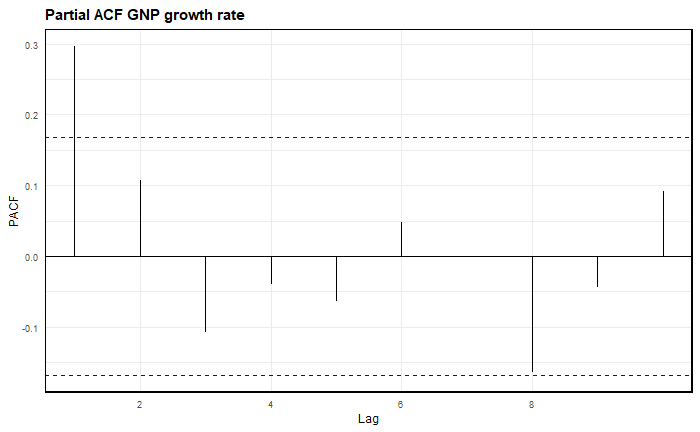

```r
ggAcf(GNP_growth, lag.max = 10 ,type = "partial", main = "Partial ACF GNP growth rate") + th
```

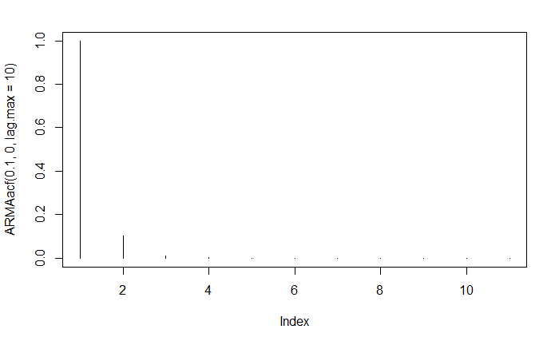

```r
# AR(1)
plot(ARMAacf(0.1, 0, lag.max = 10), type = "h")
```

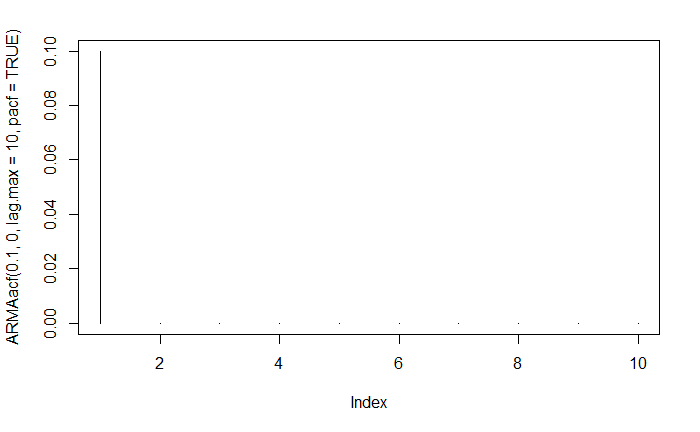

```r
plot(ARMAacf(0.1, 0, lag.max = 10, pacf =TRUE) , type = "h")
```

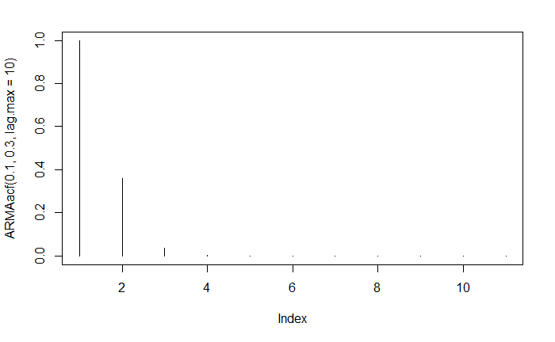

```r
# ARMA(1,1)
plot(ARMAacf(0.1, 0.3, lag.max = 10), type = "h")
```

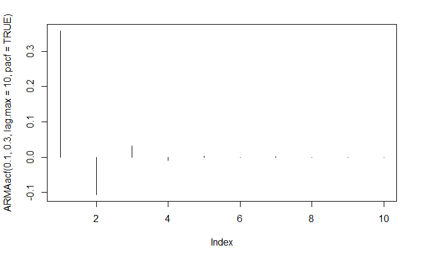

```r
plot(ARMAacf(0.1, 0.3, lag.max = 10, pacf =TRUE) , type = "h")
```

It is now time to fit the models to the data.

```r
#Models estimation
mod_1 <- arima(GNP_growth, order=c(1,0,0)) # Parmameters order follow the model name: AR - I - MA
mod_2 <- arima(GNP_growth, order=c(1,0,1))
#Reporting the coefficients estimates and their standard errors (as well as other statistics)
mod_1
```

```
Call:
arima(x = GNP_growth, order = c(1, 0, 0))

Coefficients:
         ar1  intercept
      0.2990     0.0076
s.e.  0.0823     0.0012

sigma^2 estimated as 9.358e-05:  log likelihood = 434.57,  aic = -863.14
```

```r
mod_2
```

```
Call:
arima(x = GNP_growth, order = c(1, 0, 1))

Coefficients:
         ar1      ma1  intercept
      0.4719  -0.1867     0.0076
s.e.  0.1822   0.1951     0.0013

sigma^2 estimated as 9.3e-05:  log likelihood = 434.99,  aic = -861.98
```

According to the AIC criterion, the AR(1) specification is superior. Before proceding with this specification, let’s check what the auto.arima function from the forecast package picks as a model.

```r
auto.arima(GNP_growth)
```

```
Series: GNP_growth
ARIMA(1,0,0) with non-zero mean

Coefficients:
         ar1    mean
      0.2990  0.0076
s.e.  0.0823  0.0012

sigma^2 estimated as 9.499e-05:  log likelihood=434.57
AIC=-863.14   AICc=-862.96   BIC=-854.43
```

As we can see, also the auto.arima function would have selected the AR(1) specification. We can now proceed with model diagnostic and forecasting.

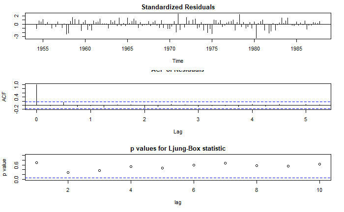

```r
# time series diagnostic
tsdiag(mod_1)
```

As we can see from the diagnostic plots, it seems that the residuals are not autocorrelated. This is evident from the ACF plot and confirmed by the p-values for the Ljung-Box statistc. We can now proceed by checking the normality of the residuals.

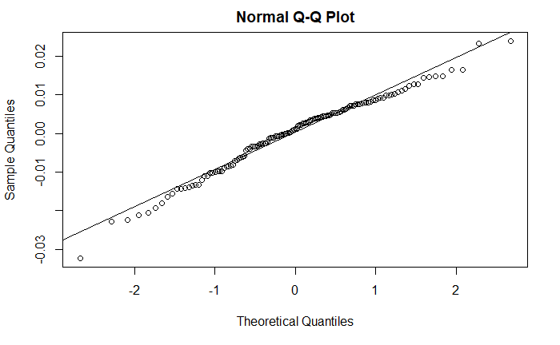

```r
# With base R functions
qqnorm(mod_1$residuals)
qqline(mod_1$residuals)
```

The normality assumption seems to be a reasonable one. Let us check this assumption with a Shapiro test.

```r
shapiro.test(mod_1$residuals)
```

```
    Shapiro-Wilk normality test

data:  mod_1$residuals
W = 0.98058, p-value = 0.05103
```

We fail to reject the null hypothesis of normality at the 5% confidence level. Normality seems to be a good assumptions for the residuals’ distribution. Let’s now forecast the series. As a first step, let us look at how the model qould hae performed looking backwards, then let’s give some projections.

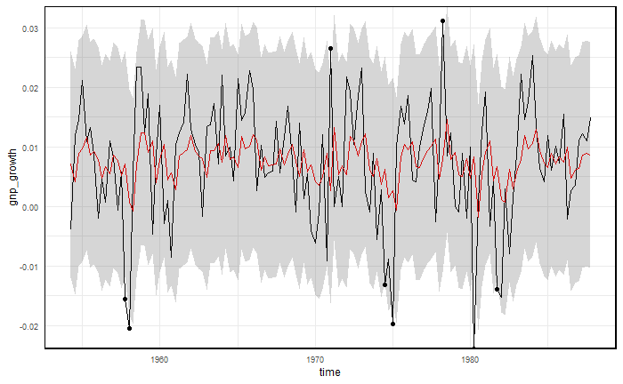

```r
# R functions
upper <- fitted(mod_1) + 1.96*sqrt(mod_1$sigma2)
lower <- fitted(mod_1) - 1.96*sqrt(mod_1$sigma2)
#plot(gnp_growth, type="n", ylim=range(lower,upper))
#polygon(c(time(gnp_growth),rev(time(gnp_growth))), c(upper,rev(lower)),
#   col=rgb(0,0,0.6,0.2), border=FALSE)
#lines(gnp_growth)
#lines(fitted(mod_1),col='red')
out <- (gnp_growth < lower | gnp_growth > upper)
#points(time(gnp_growth)[out], gnp_growth[out], pch=19)
# ggplot
out = out*gnp_growth
out[out == FALSE] = NA
ggplot(data = data.frame(time = time(gnp_growth),gnp_growth, fitted = fitted(mod_1), upper, lower, out), aes(x = time, y = gnp_growth)) + th +
  geom_line(aes(y = gnp_growth)) +
  geom_line(aes(y = fitted), col = "red") +
  scale_y_continuous(expand = c(0,0)) +
  geom_ribbon(aes(ymin=lower, ymax=upper), alpha = 0.2) +
  geom_point(aes(y = out))
```

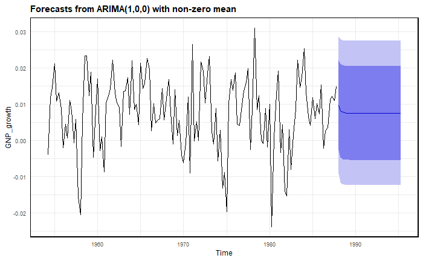

```r
autoplot(forecast(mod_1, h = 30)) + th
```

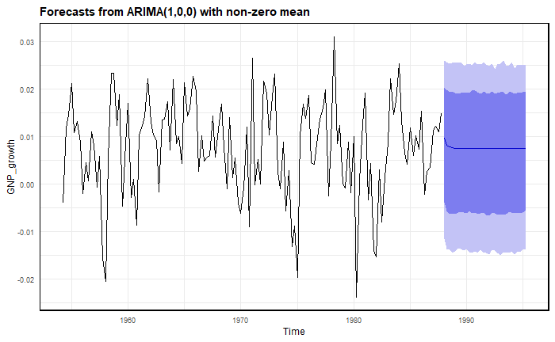

```r
# With bootstrapped confidence interval
autoplot(forecast(mod_1, h = 30, bootstrap = TRUE)) + th
```